# Unit 02.B: Intro to R and RStudio

## Exercise 3: Exploring themes in the letters

1. Expectations about the plot will vary

```r
ggplot(abby, aes(x = themes)) +
    geom_bar() +
    theme(axis.text.x = element_text(angle = 90, vjust = 0.5, hjust=1))
```

[output not shown]

2. Counts in the table below match the barplot

```r
# Construct a table of counts
abby %>%
    count(themes)
## # A tibble: 8 × 2
##   themes                       n
##   <chr>                    <int>
## 1 marriage                    75
## 2 marriage, money              5
## 3 money                       21
## 4 other                      234
## 5 parents                    127
## 6 parents, marriage           33
## 7 parents, marriage, money     4
## 8 parents, money              15
```

3. What do the plot layers do?

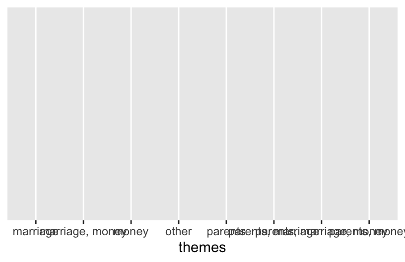

```r
# Just sets up the "canvas" of the plot with axis labels
ggplot(abby, aes(x = themes))
```

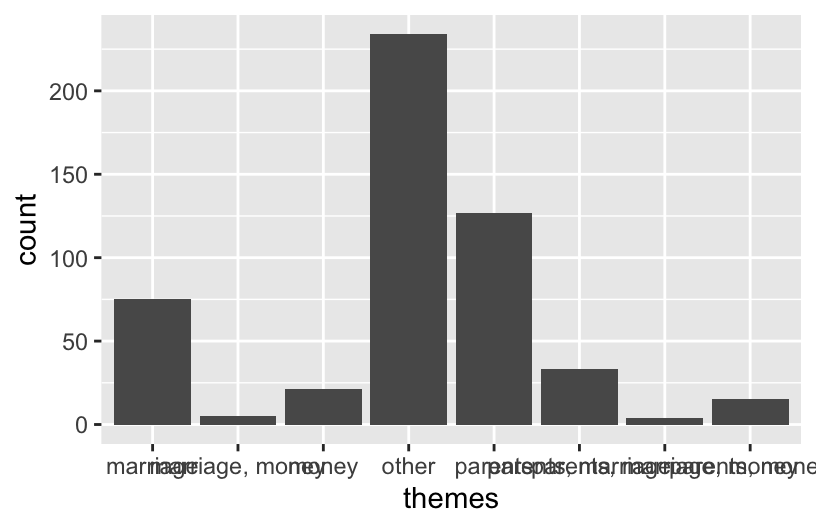

```r
# Adds the bars
ggplot(abby, aes(x = themes)) +
    geom_bar()
```

```r
# Rotates the x axis labels
ggplot(abby, aes(x = themes)) +
    geom_bar() +
    theme(axis.text.x = element_text(angle = 90, vjust = 0.5, hjust=1))
```

[output not shown]

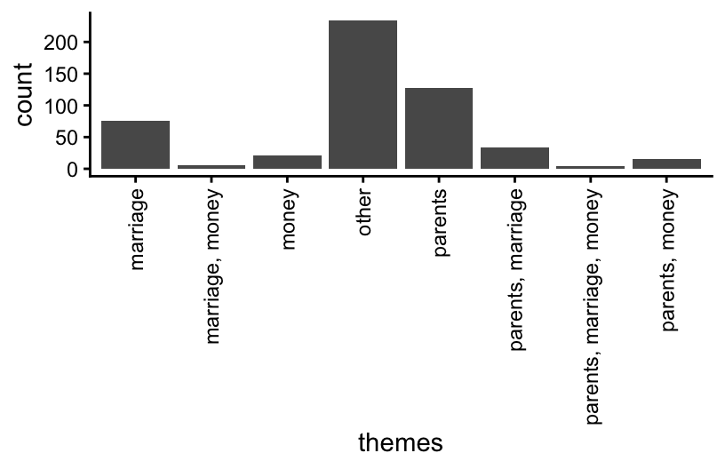

```r
# Changes the visual theme of the plot with a white background and removes gridlines
ggplot(abby, aes(x = themes)) +
    geom_bar() +
    theme_classic() +
    theme(axis.text.x = element_text(angle = 90, vjust = 0.5, hjust=1))
```

## Exercise 8: Read in and get to know the weather data

```r
weather <- read_csv("https://raw.githubusercontent.com/Mac-STAT/data/main/weather_3_locations.csv")
```

## Exercise 9: Exploring the data structure

Check out the basic features of the weather data.

```r
# Examine the first six cases
head(weather)
## # A tibble: 6 × 24
##   date       location  mintemp maxtemp rainfall evaporation sunshine windgustdir
##   <date>     <chr>       <dbl>   <dbl>    <dbl>       <dbl>    <dbl> <chr>
## 1 2020-01-01 Wollongo…    17.1    23.1        0          NA       NA SSW
## 2 2020-01-02 Wollongo…    17.7    24.2        0          NA       NA SSW
## 3 2020-01-03 Wollongo…    19.7    26.8        0          NA       NA NE
## 4 2020-01-04 Wollongo…    20.4    35.5        0          NA       NA SSW
## 5 2020-01-05 Wollongo…    19.8    21.4        0          NA       NA SSW
## 6 2020-01-06 Wollongo…    18.3    22.9        0          NA       NA NE
## # ℹ 16 more variables: windgustspeed <dbl>, winddir9am <chr>, winddir3pm <chr>,
## #   windspeed9am <dbl>, windspeed3pm <dbl>, humidity9am <dbl>,
## #   humidity3pm <dbl>, pressure9am <dbl>, pressure3pm <dbl>, cloud9am <dbl>,
## #   cloud3pm <dbl>, temp9am <dbl>, temp3pm <dbl>, raintoday <chr>,
## #   risk_mm <dbl>, raintomorrow <chr>

# Find the dimensions of the data
dim(weather)
## [1] 2367   24
```

A case represents a day of the year in a particular area (Hobart, Uluru, Wollongong as seen by the `location` variable).

## Exercise 10: Exploring rainfall

The `raintoday` variable contains information about rainfall.

- `raintoday` is categorical (No, Yes)
- It is more common to have no rain.

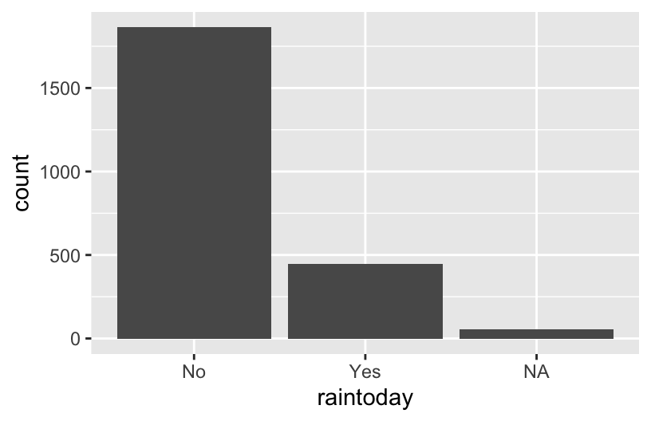

```r
# Visualization
ggplot(weather, aes(x = raintoday)) +
    geom_bar()
```

```r
# Numerical summaries
weather %>%
    count(raintoday)
## # A tibble: 3 × 2
##   raintoday     n
##   <chr>     <int>
## 1 No         1864
## 2 Yes         446
## 3 <NA>         57
```

## Exercise 11: Exploring temperature

The `maxtemp` variable contains information on the daily high temperature.

- `maxtemp` is quantitative
- The *typical* max temperature is around 23 degrees Celsius (with an average of 23.62 and a median of 22 degrees). The max temperatures ranged from 8.6 to 45.4 degrees. Finally, on the typical day, the max temp falls about 7.8 degrees from the mean. There are multiple modes in the distribution of max temperature—this likely reflects the different cities in the dataset.

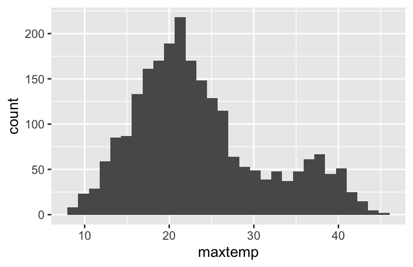

```r
# Visualization
ggplot(weather, aes(x = maxtemp)) +
    geom_histogram()
```

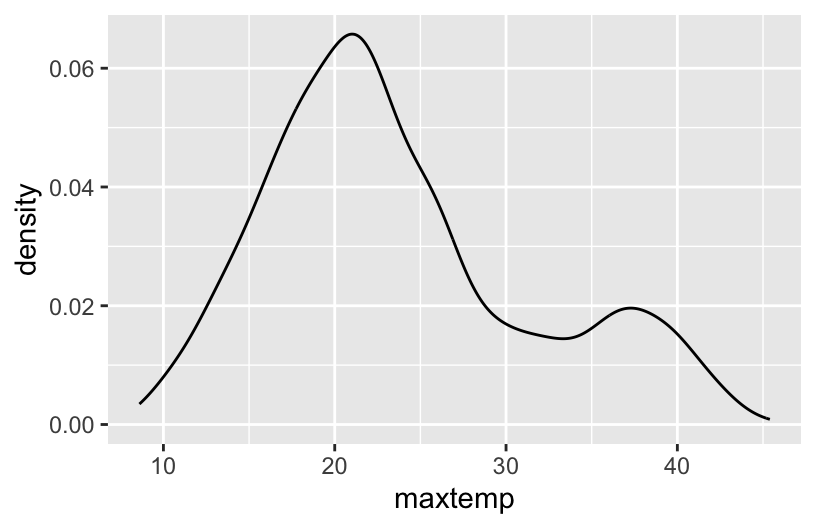

```r
# Density plot
ggplot(weather, aes(x = maxtemp)) +
    geom_density()
```

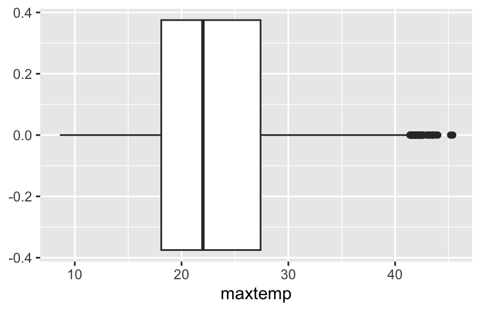

```r
# Box plot
ggplot(weather, aes(x = maxtemp)) +
    geom_boxplot()
```

```r
# Numerical summaries
summary(weather$maxtemp)
##    Min. 1st Qu.  Median    Mean 3rd Qu.    Max.    NA's
##    8.60   18.10   22.00   23.62   27.40   45.40      34

# There are missing values (NAs) in this variable, so we add
# the na.rm = TRUE argument
weather %>%
    summarize(sd(maxtemp, na.rm = TRUE))
## # A tibble: 1 × 1
##   `sd(maxtemp, na.rm = TRUE)`
##                         <dbl>
## 1                        7.80
```